# Entrega_empresas_coches

Matias Corredoira

29/11/2020

## Practica:

Para este caso realizaremos los punto s 1 y 3 en los que se estimará un modelo Garch para BMW y se planteará un modelo mensual para ambos activos

### Cargamos las librerías necesarias para el trabajo

```r
library(quantmod)
library(forecast)
library(fGarch)
library(vars)
```

##### Multiplicador de Lagrange para el efecto ARCH de una serie de tiempo

rtn: time series m: selected AR order TSAY(2013)

Su aplicación se usará para comprobar la necesidad de estimación de un modelo GARCH

#### Crgamos los datos y los marcamos como procede.

```r
sSymbol="BMW.DE"
# Recogemos datos
mData<-getSymbols(sSymbol ,from="2014-01-01",to="2020-01-01",auto.assign=FALSE)
#Realizamos su definición
xData=Ad(mData)
# Mediaa arirmetica
dRentCont=dailyReturn(xData,type='log',leading=FALSE)
# Eliminamos valorea NA
dRentCont=na.exclude(dRentCont)
```

##### Se grafican las rentabilidades pertenecientes a los distintos años.

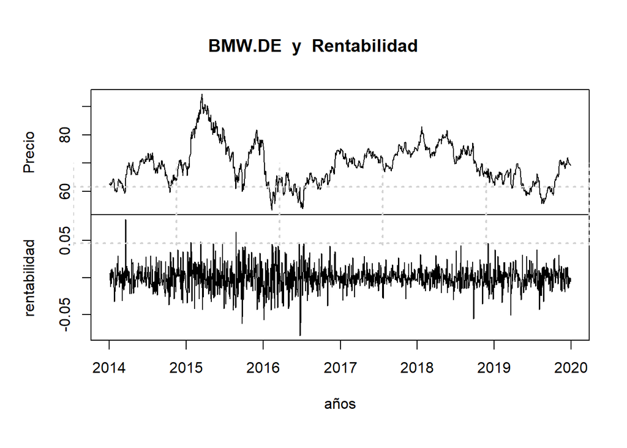

```r
plot.zoo(cbind(xData,dRentCont),main=paste(sSymbol," y  Rentabilidad"),xlab="años",ylab=c("Precio","rentabilidad"))
grid(lwd=2)
```

##### Graficamos volatilidad de GARP

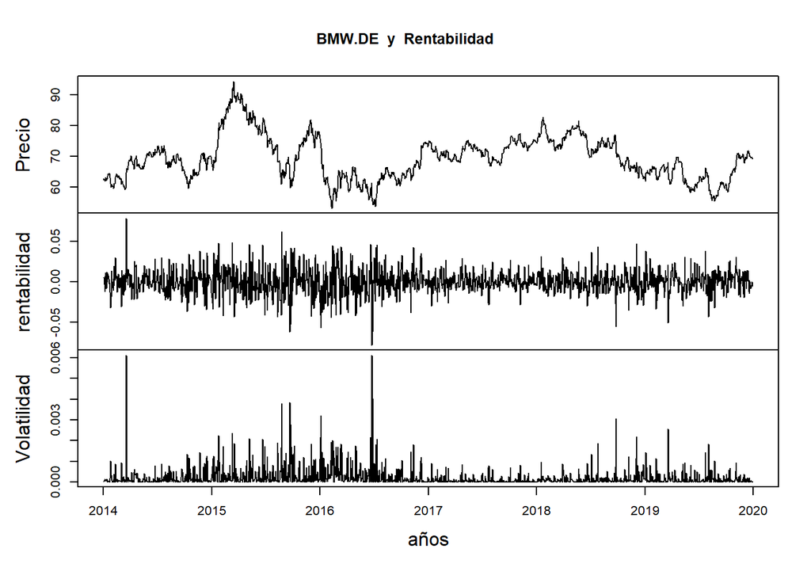

```r
# Graficamos aplicandoles el cuadrado
plot.zoo(cbind(Ad(mData),dRentCont,dRentCont^2),main=paste(sSymbol," y  Rentabilidad"),xlab="años",ylab=c("Precio","rentabilidad","Volatilidad"))
```

##### Realizamos el test sobre la media

```r
t.test(dRentCont)
```

```
##
##  One Sample t-test
##
## data:  dRentCont
## t = 0.17599, df = 1517, p-value = 0.8603
## alternative hypothesis: true mean is not equal to 0
## 95 percent confidence interval:
##  -0.0006889777  0.0008247909
## sample estimates:
##    mean of x
## 6.790663e-05
```

### ACF & PACF

ACF es una función de autocorrelación (completa) que nos da valores de autocorrelación de cualquier serie con sus valores retardados. El PACF es una función de autocorrelación parcial. Básicamente, en lugar de encontrar correlaciones de presente con desfases como el ACF, encuentra una correlación de los residuos (que permanece después de eliminar los efectos que ya se explican por los desfases anteriores) con el siguiente valor de desfase, por lo tanto, “parcial” y no “completa”, ya que eliminamos las variaciones ya encontradas antes de encontrar la siguiente correlación.

```r
#ACF & PACF
# VolProxy=abs(dRentCont) # absolute value
VolProxy=dRentCont^2
```

Para determinar si existen efectos GARCH en la serie de residuos del modelo, realizamos las pruebas de hipótesis: Ljung-Box y Multiplicador de Lagrange para efectos GARCH. El resultado de estas pruebas, nos indicará si es necesario realizar la estimación de un modelo GARCH.

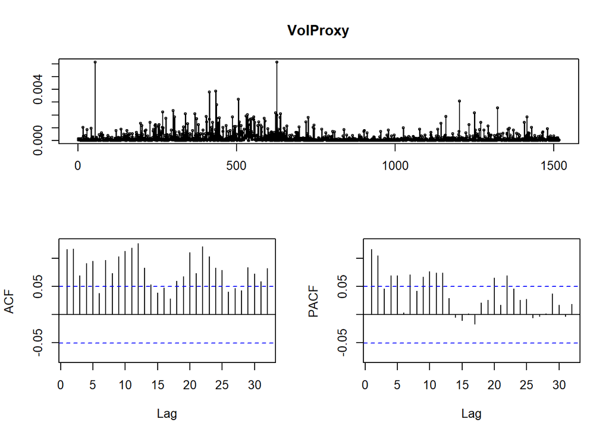

```r
#ACF y PACF
tsdisplay(VolProxy)
```

```r
#Ljung-Box Test
Box.test(VolProxy,lag=10,  type="Lj")
```

```
##
##  Box-Ljung test
##
## data:  VolProxy
## X-squared = 135.56, df = 10, p-value < 2.2e-16
```

```r
Box.test(VolProxy,lag=20,  type="Lj")
```

```
##
##  Box-Ljung test
##
## data:  VolProxy
## X-squared = 234.88, df = 20, p-value < 2.2e-16
```

```r
Box.test(VolProxy,lag=40,  type="Lj")
```

```
##
##  Box-Ljung test
##
## data:  VolProxy
## X-squared = 397.71, df = 40, p-value < 2.2e-16
```

```r
#LM test
archTest(dRentCont,20)
```

```
##
## Call:
## lm(formula = atsq ~ x)
##
## Residuals:
##        Min         1Q     Median         3Q        Max
## -0.0007212 -0.0001736 -0.0001128  0.0000149  0.0059128
##
## Coefficients:
##               Estimate Std. Error t value Pr(>|t|)
## (Intercept)  8.582e-05  1.939e-05   4.426 1.03e-05 ***
## x1           6.376e-02  2.596e-02   2.456  0.01417 *
## x2           6.562e-02  2.601e-02   2.523  0.01174 *
## x3           1.595e-02  2.606e-02   0.612  0.54067
## x4           4.825e-02  2.606e-02   1.851  0.06433 .
## x5           5.151e-02  2.606e-02   1.977  0.04825 *
## x6          -1.727e-02  2.609e-02  -0.662  0.50811
## x7           4.821e-02  2.609e-02   1.848  0.06487 .
## x8           1.732e-02  2.611e-02   0.663  0.50728
## x9           4.520e-02  2.605e-02   1.735  0.08289 .
## x10          6.010e-02  2.603e-02   2.309  0.02107 *
## x11          6.198e-02  2.603e-02   2.382  0.01737 *
## x12          7.166e-02  2.605e-02   2.751  0.00602 **
## x13          2.719e-02  2.611e-02   1.041  0.29792
## x14         -4.645e-03  2.609e-02  -0.178  0.85872
## x15         -1.335e-02  2.609e-02  -0.512  0.60904
## x16         -1.505e-03  2.606e-02  -0.058  0.95396
## x17         -2.106e-02  2.603e-02  -0.809  0.41867
## x18          1.528e-02  2.603e-02   0.587  0.55724
## x19          2.132e-02  2.598e-02   0.821  0.41206
## x20          6.519e-02  2.593e-02   2.514  0.01204 *
## ---
## Signif. codes:  0 '***' 0.001 '**' 0.01 '*' 0.05 '.' 0.1 ' ' 1
##
## Residual standard error: 0.0004452 on 1477 degrees of freedom
## Multiple R-squared:  0.06908,    Adjusted R-squared:  0.05647
## F-statistic:  5.48 on 20 and 1477 DF,  p-value: 9e-14
```

### ARCH(1)

El modelo ARCH es la primera especificación y desarrollo del modelo

```r
#ARCH(1)
m1=garchFit(~1+garch(1,0),data=dRentCont,trace=F) # Fit an ARCH(1) model
summary(m1)
```

```
##
## Title:
##  GARCH Modelling
##
## Call:
##  garchFit(formula = ~1 + garch(1, 0), data = dRentCont, trace = F)
##
## Mean and Variance Equation:
##  data ~ 1 + garch(1, 0)
## <environment: 0x000000002148da68>
##  [data = dRentCont]
##
## Conditional Distribution:
##  norm
##
## Coefficient(s):
##         mu       omega      alpha1
## 0.00018448  0.00019441  0.14298744
##
## Std. Errors:
##  based on Hessian
##
## Error Analysis:
##         Estimate  Std. Error  t value Pr(>|t|)
## mu     1.845e-04   3.792e-04    0.486    0.627
## omega  1.944e-04   8.954e-06   21.711  < 2e-16 ***
## alpha1 1.430e-01   3.471e-02    4.119  3.8e-05 ***
## ---
## Signif. codes:  0 '***' 0.001 '**' 0.01 '*' 0.05 '.' 0.1 ' ' 1
##
## Log Likelihood:
##  4234.426    normalized:  2.789477
##
## Description:
##  Mon Nov 30 22:15:17 2020 by user: matia
##
##
## Standardised Residuals Tests:
##                                 Statistic p-Value
##  Jarque-Bera Test   R    Chi^2  253.3086  0
##  Shapiro-Wilk Test  R    W      0.9777482 1.391266e-14
##  Ljung-Box Test     R    Q(10)  28.28342  0.001625876
##  Ljung-Box Test     R    Q(15)  35.04017  0.002426856
##  Ljung-Box Test     R    Q(20)  45.31624  0.0009995332
##  Ljung-Box Test     R^2  Q(10)  72.67757  1.344713e-11
##  Ljung-Box Test     R^2  Q(15)  111.716   1.110223e-16
##  Ljung-Box Test     R^2  Q(20)  134.536   0
##  LM Arch Test       R    TR^2   67.02175  1.150442e-09
##
## Information Criterion Statistics:
##       AIC       BIC       SIC      HQIC
## -5.575001 -5.564477 -5.575009 -5.571083
```

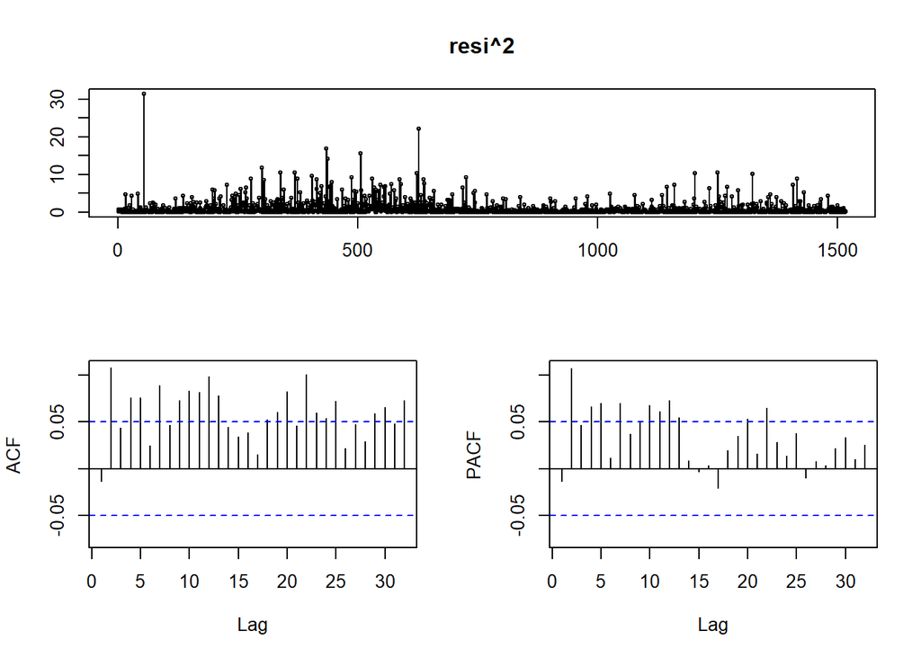

```r
resi=residuals(m1,standardize=T) #residuals
resi=xts(resi,order.by=index(dRentCont)) #residuals as xts
tsdisplay(resi^2) #acf pacf residuals
```

### GARCH (1,1)

Metodo generalizado y sin restricciones para la estimacion de los parametros ARCH con infinitos retardos

```r
#GARCH(1,1)
m2=garchFit(~1+garch(1,1),data=dRentCont,trace=F) # Fit an GARCH(1,1) model
summary(m2)
```

```
##
## Title:
##  GARCH Modelling
##
## Call:
##  garchFit(formula = ~1 + garch(1, 1), data = dRentCont, trace = F)
##
## Mean and Variance Equation:
##  data ~ 1 + garch(1, 1)
## <environment: 0x000000001cfac9b0>
##  [data = dRentCont]
##
## Conditional Distribution:
##  norm
##
## Coefficient(s):
##         mu       omega      alpha1       beta1
## 2.3609e-04  6.5052e-07  2.1211e-02  9.7560e-01
##
## Std. Errors:
##  based on Hessian
##
## Error Analysis:
##         Estimate  Std. Error  t value Pr(>|t|)
## mu     2.361e-04   3.409e-04    0.693   0.4886
## omega  6.505e-07   3.355e-07    1.939   0.0525 .
## alpha1 2.121e-02   3.642e-03    5.823 5.77e-09 ***
## beta1  9.756e-01   3.903e-03  249.957  < 2e-16 ***
## ---
## Signif. codes:  0 '***' 0.001 '**' 0.01 '*' 0.05 '.' 0.1 ' ' 1
##
## Log Likelihood:
##  4307.9    normalized:  2.837879
##
## Description:
##  Mon Nov 30 22:15:18 2020 by user: matia
##
##
## Standardised Residuals Tests:
##                                 Statistic p-Value
##  Jarque-Bera Test   R    Chi^2  242.9076  0
##  Shapiro-Wilk Test  R    W      0.9841121 6.901744e-12
##  Ljung-Box Test     R    Q(10)  26.63639  0.002972279
##  Ljung-Box Test     R    Q(15)  31.85092  0.006745725
##  Ljung-Box Test     R    Q(20)  38.52619  0.007631821
##  Ljung-Box Test     R^2  Q(10)  3.765989  0.9572868
##  Ljung-Box Test     R^2  Q(15)  4.943707  0.9925924
##  Ljung-Box Test     R^2  Q(20)  8.35668   0.9892325
##  LM Arch Test       R    TR^2   4.321407  0.9769137
##
## Information Criterion Statistics:
##       AIC       BIC       SIC      HQIC
## -5.670488 -5.656456 -5.670502 -5.665264
```

##### Representamos los residuos

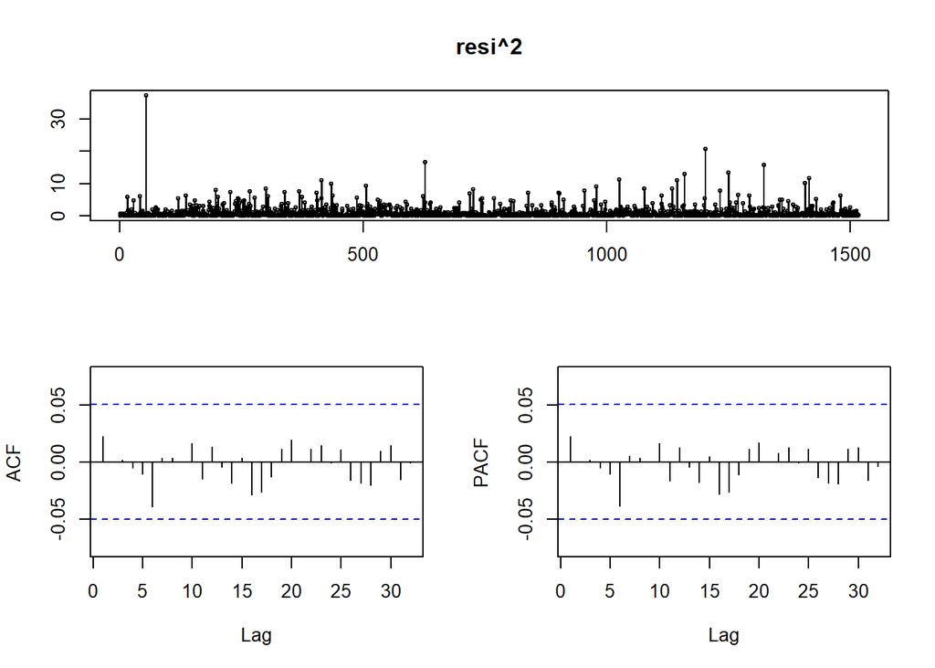

```r
resi=residuals(m2,standardize=T) #residuals
resi=xts(resi,order.by=index(dRentCont)) #residuals as xts
tsdisplay(resi^2) #acf pacf residuals
```

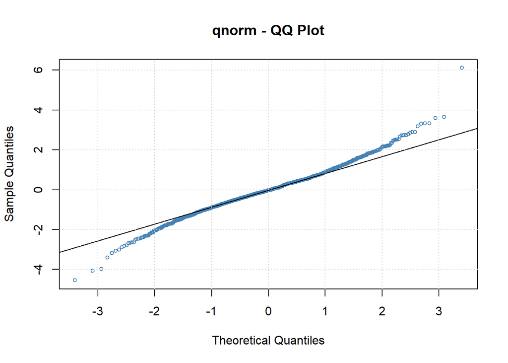

```r
plot(m2,which=13)
```

```r
m3=garchFit(~1+garch(1,1),data=dRentCont,trace=F,cond.dist="std")
summary(m3)
```

```
##
## Title:
##  GARCH Modelling
##
## Call:
##  garchFit(formula = ~1 + garch(1, 1), data = dRentCont, cond.dist = "std",
##     trace = F)
##
## Mean and Variance Equation:
##  data ~ 1 + garch(1, 1)
## <environment: 0x0000000021a223a0>
##  [data = dRentCont]
##
## Conditional Distribution:
##  std
##
## Coefficient(s):
##          mu        omega       alpha1        beta1        shape
## -8.4249e-06   5.3421e-07   2.7337e-02   9.7108e-01   5.8155e+00
##
## Std. Errors:
##  based on Hessian
##
## Error Analysis:
##          Estimate  Std. Error  t value Pr(>|t|)
## mu     -8.425e-06   3.167e-04   -0.027    0.979
## omega   5.342e-07   4.752e-07    1.124    0.261
## alpha1  2.734e-02   6.104e-03    4.478 7.52e-06 ***
## beta1   9.711e-01   6.211e-03  156.344  < 2e-16 ***
## shape   5.816e+00   8.861e-01    6.563 5.26e-11 ***
## ---
## Signif. codes:  0 '***' 0.001 '**' 0.01 '*' 0.05 '.' 0.1 ' ' 1
##
## Log Likelihood:
##  4346.247    normalized:  2.86314
##
## Description:
##  Mon Nov 30 22:15:18 2020 by user: matia
##
##
## Standardised Residuals Tests:
##                                 Statistic p-Value
##  Jarque-Bera Test   R    Chi^2  273.2358  0
##  Shapiro-Wilk Test  R    W      0.9831637 2.493756e-12
##  Ljung-Box Test     R    Q(10)  26.7424   0.002860125
##  Ljung-Box Test     R    Q(15)  32.07828  0.006282003
##  Ljung-Box Test     R    Q(20)  39.00589  0.006656149
##  Ljung-Box Test     R^2  Q(10)  3.663611  0.961249
##  Ljung-Box Test     R^2  Q(15)  5.354329  0.9886775
##  Ljung-Box Test     R^2  Q(20)  8.828362  0.9848113
##  LM Arch Test       R    TR^2   4.609628  0.9697647
##
## Information Criterion Statistics:
##       AIC       BIC       SIC      HQIC
## -5.719692 -5.702152 -5.719714 -5.713162
```

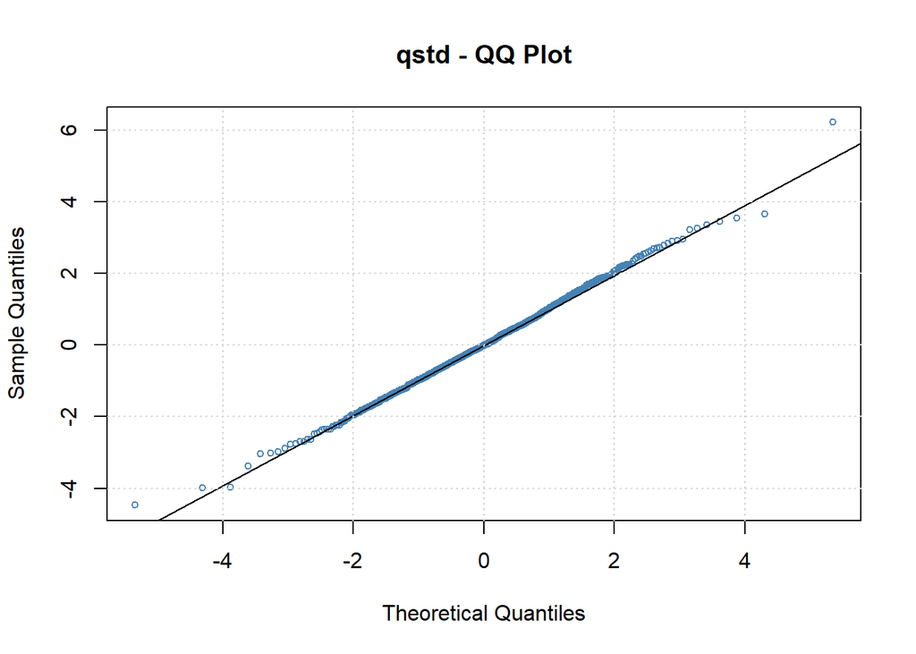

```r
plot(m3,which =13)
```

# Volatilidad

la volatilidad es una medida de cuánto la rentabilidad fluctúa alrededor de su media. Es por tanto una medida del riesgo. Por lo tanto, es importante, poder calcular esta volatilidad en cualquier instante, para analizar cómo varía con el tiempo y para predecir sus valores futuros.

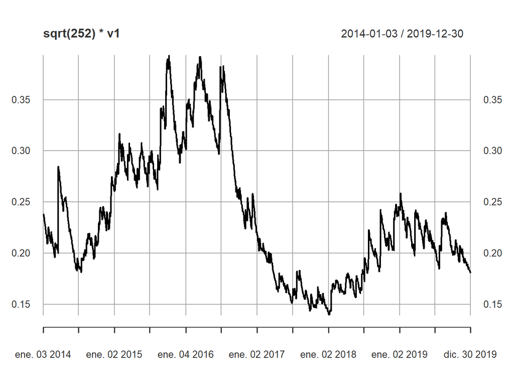

```r
v1=volatility(m3)
v1=xts(v1,order.by=index(dRentCont))
plot(sqrt(252)*v1)
```

Estandarizamos los residuos y los plasmamos

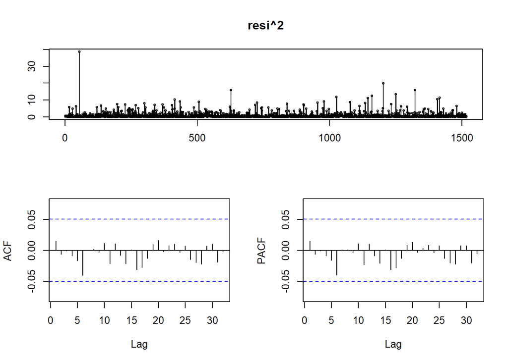

```r
resi=residuals(m3,standardize=T) # Standardized residuals
resi=xts(resi,order.by=index(dRentCont)) # Standardized residuals as XTS
tsdisplay(resi^2) #acf pacf residuals
```

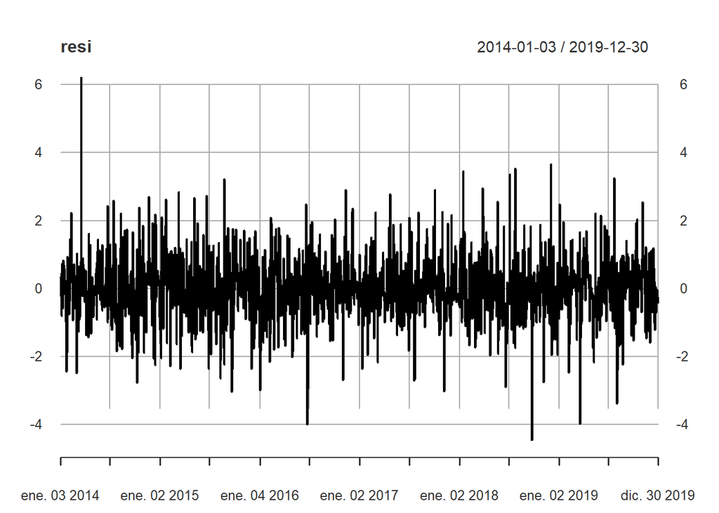

```r
plot(resi)
```

# Por ultimo predecimos la volatilidad de nuestro modelo, es decir el riesgo

```r
predict(m3) #forecast volatility
```

```
##     meanForecast  meanError standardDeviation
## 1  -8.424914e-06 0.01125847        0.01125847
## 2  -8.424914e-06 0.01127329        0.01127329
## 3  -8.424914e-06 0.01128806        0.01128806
## 4  -8.424914e-06 0.01130279        0.01130279
## 5  -8.424914e-06 0.01131748        0.01131748
## 6  -8.424914e-06 0.01133213        0.01133213
## 7  -8.424914e-06 0.01134673        0.01134673
## 8  -8.424914e-06 0.01136129        0.01136129
## 9  -8.424914e-06 0.01137582        0.01137582
## 10 -8.424914e-06 0.01139030        0.01139030
```

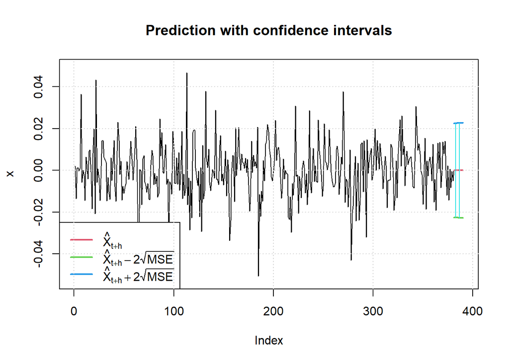

```
##     meanForecast  meanError standardDeviation lowerInterval upperInterval
## 1  -8.424914e-06 0.01125847        0.01125847   -0.02252536    0.02250851
## 2  -8.424914e-06 0.01127329        0.01127329   -0.02255500    0.02253815
## 3  -8.424914e-06 0.01128806        0.01128806   -0.02258455    0.02256770
## 4  -8.424914e-06 0.01130279        0.01130279   -0.02261401    0.02259716
## 5  -8.424914e-06 0.01131748        0.01131748   -0.02264339    0.02262654
## 6  -8.424914e-06 0.01133213        0.01133213   -0.02267268    0.02265583
## 7  -8.424914e-06 0.01134673        0.01134673   -0.02270189    0.02268504
## 8  -8.424914e-06 0.01136129        0.01136129   -0.02273101    0.02271416
## 9  -8.424914e-06 0.01137582        0.01137582   -0.02276006    0.02274321
## 10 -8.424914e-06 0.01139030        0.01139030   -0.02278902    0.02277217
```

```r
predict(m3, n.ahead = 10, plot=TRUE, crit_val=2) #plot with 2*standard error
```

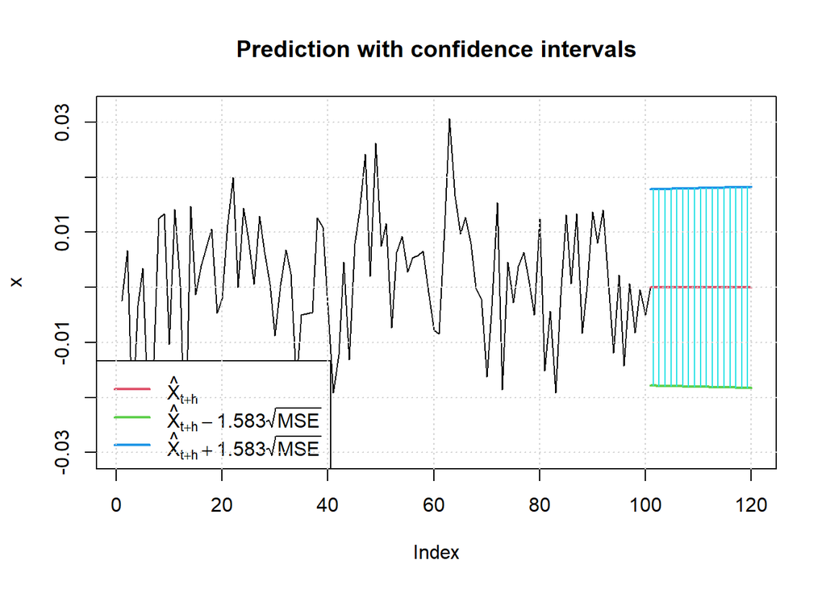

```
##     meanForecast  meanError standardDeviation lowerInterval upperInterval
## 1  -8.424914e-06 0.01125847        0.01125847   -0.01783007    0.01781322
## 2  -8.424914e-06 0.01127329        0.01127329   -0.01785353    0.01783668
## 3  -8.424914e-06 0.01128806        0.01128806   -0.01787691    0.01786006
## 4  -8.424914e-06 0.01130279        0.01130279   -0.01790023    0.01788338
## 5  -8.424914e-06 0.01131748        0.01131748   -0.01792348    0.01790663
## 6  -8.424914e-06 0.01133213        0.01133213   -0.01794667    0.01792982
## 7  -8.424914e-06 0.01134673        0.01134673   -0.01796979    0.01795294
## 8  -8.424914e-06 0.01136129        0.01136129   -0.01799284    0.01797599
## 9  -8.424914e-06 0.01137582        0.01137582   -0.01801582    0.01799897
## 10 -8.424914e-06 0.01139030        0.01139030   -0.01803875    0.01802190
## 11 -8.424914e-06 0.01140473        0.01140473   -0.01806160    0.01804475
## 12 -8.424914e-06 0.01141913        0.01141913   -0.01808439    0.01806754
## 13 -8.424914e-06 0.01143349        0.01143349   -0.01810712    0.01809027
## 14 -8.424914e-06 0.01144780        0.01144780   -0.01812978    0.01811293
## 15 -8.424914e-06 0.01146208        0.01146208   -0.01815238    0.01813553
## 16 -8.424914e-06 0.01147631        0.01147631   -0.01817491    0.01815806
## 17 -8.424914e-06 0.01149051        0.01149051   -0.01819738    0.01818053
## 18 -8.424914e-06 0.01150467        0.01150467   -0.01821979    0.01820294
## 19 -8.424914e-06 0.01151878        0.01151878   -0.01824213    0.01822528
## 20 -8.424914e-06 0.01153286        0.01153286   -0.01826441    0.01824756
```

```r
predict(m3,n.ahead=20,plot=TRUE,conf=.9,nx=100) # plot 100 data with 90% confidence
```

## Modelo VAR

```r
bmw=getSymbols("BMW.DE",env=NULL)
vol=getSymbols("VWAGY",env=NULL)
```

### Marcamos rentabilidad mensual

```r
rbmw=monthlyReturn(bmw[,6])
rvol=monthlyReturn(vol[,6])
```

```r
vY=cbind(rbmw,rvol)
colnames(vY)=c("BMW","VOL")
vY=na.omit(vY)
```

### Seleccionamos modelo

```r
VARselect(vY)
```

```
## $selection
## AIC(n)  HQ(n)  SC(n) FPE(n)
##      2      2      2      2
##
## $criteria
##                    1    2    3    4    5    6    7    8    9   10
## AIC(n) -4.391959e+01 -Inf -Inf -Inf -Inf -Inf -Inf -Inf -Inf -Inf
## HQ(n)  -4.593969e+01 -Inf -Inf -Inf -Inf -Inf -Inf -Inf -Inf -Inf
## SC(n)  -4.484015e+01 -Inf -Inf -Inf -Inf -Inf -Inf -Inf -Inf -Inf
## FPE(n)  2.057200e-19    0    0    0    0    0    0    0    0    0
```

### Estimación

```r
model.var=VAR(vY)
summary(model.var)
```

```
##
## VAR Estimation Results:
## =========================
## Endogenous variables: BMW, VOL
## Deterministic variables: const
## Sample size: 13
## Log Likelihood: 34.903
## Roots of the characteristic polynomial:
## 0.434 0.1406
## Call:
## VAR(y = vY)
##
##
## Estimation results for equation BMW:
## ====================================
## BMW = BMW.l1 + VOL.l1 + const
##
##        Estimate Std. Error t value Pr(>|t|)
## BMW.l1 -0.07643    0.94710  -0.081    0.937
## VOL.l1 -0.06376    0.91166  -0.070    0.946
## const   0.02113    0.03602   0.586    0.571
##
##
## Residual standard error: 0.1292 on 10 degrees of freedom
## Multiple R-Squared: 0.01357, Adjusted R-squared: -0.1837
## F-statistic: 0.06879 on 2 and 10 DF,  p-value: 0.934
##
##
## Estimation results for equation VOL:
## ====================================
## VOL = BMW.l1 + VOL.l1 + const
##
##        Estimate Std. Error t value Pr(>|t|)
## BMW.l1  0.35965    0.94896   0.379    0.713
## VOL.l1 -0.49814    0.91345  -0.545    0.597
## const   0.01587    0.03609   0.440    0.669
##
##
## Residual standard error: 0.1294 on 10 degrees of freedom
## Multiple R-Squared: 0.03759, Adjusted R-squared: -0.1549
## F-statistic: 0.1953 on 2 and 10 DF,  p-value: 0.8257
##
##
##
## Covariance matrix of residuals:
##         BMW     VOL
## BMW 0.01668 0.01589
## VOL 0.01589 0.01675
##
## Correlation matrix of residuals:
##        BMW    VOL
## BMW 1.0000 0.9505
## VOL 0.9505 1.0000
```

```r
model.var1=VAR(vY,type="none")
summary(model.var1)
```

```
##
## VAR Estimation Results:
## =========================
## Endogenous variables: BMW, VOL
## Deterministic variables: none
## Sample size: 13
## Log Likelihood: 34.594
## Roots of the characteristic polynomial:
## 0.4242 0.127
## Call:
## VAR(y = vY, type = "none")
##
##
## Estimation results for equation BMW:
## ====================================
## BMW = BMW.l1 + VOL.l1
##
##        Estimate Std. Error t value Pr(>|t|)
## BMW.l1 -0.02059    0.91377  -0.023    0.982
## VOL.l1 -0.10695    0.88117  -0.121    0.906
##
##
## Residual standard error: 0.1252 on 11 degrees of freedom
## Multiple R-Squared: 0.01144, Adjusted R-squared: -0.1683
## F-statistic: 0.06368 on 2 and 11 DF,  p-value: 0.9387
##
##
## Estimation results for equation VOL:
## ====================================
## VOL = BMW.l1 + VOL.l1
##
##        Estimate Std. Error t value Pr(>|t|)
## BMW.l1   0.4016     0.9089   0.442    0.667
## VOL.l1  -0.5306     0.8764  -0.605    0.557
##
##
## Residual standard error: 0.1246 on 11 degrees of freedom
## Multiple R-Squared: 0.03907, Adjusted R-squared: -0.1356
## F-statistic: 0.2236 on 2 and 11 DF,  p-value: 0.8032
##
##
##
## Covariance matrix of residuals:
##         BMW     VOL
## BMW 0.01517 0.01445
## VOL 0.01445 0.01523
##
## Correlation matrix of residuals:
##        BMW    VOL
## BMW 1.0000 0.9505
## VOL 0.9505 1.0000
```

### Causalidad de granger

```r
causality(model.var1)
```

```
## $Granger
##
##  Granger causality H0: BMW do not Granger-cause VOL
##
## data:  VAR object model.var1
## F-Test = 0.19524, df1 = 1, df2 = 22, p-value = 0.6629
##
##
## $Instant
##
##  H0: No instantaneous causality between: BMW and VOL
##
## data:  VAR object model.var1
## Chi-squared = 6.1722, df = 1, p-value = 0.01298
```

### Respuesta al impulso

```r
model.ri=irf(model.var1)
model.ri
```

```
##
## Impulse response coefficients
## $BMW
##                 BMW           VOL
##  [1,]  1.252487e-01  1.184460e-01
##  [2,] -1.524704e-02 -1.254649e-02
##  [3,]  1.655827e-03  5.338327e-04
##  [4,] -9.119081e-05  3.817359e-04
##  [5,] -3.894921e-05 -2.391688e-04
##  [6,]  2.638137e-05  1.112592e-04
##  [7,] -1.244252e-05 -4.843851e-05
##  [8,]  5.436762e-06  2.070419e-05
##  [9,] -2.326287e-06 -8.802080e-06
## [10,]  9.892939e-07  3.736080e-06
## [11,] -4.199489e-07 -1.585035e-06
```

[output cut: 74 more lines]

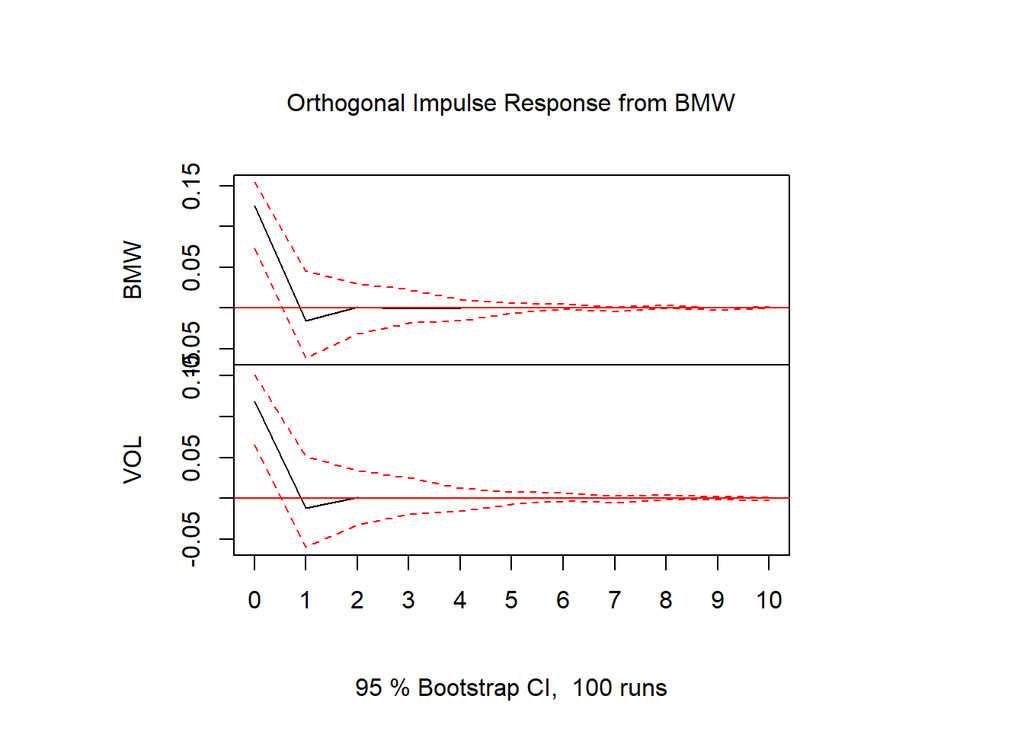

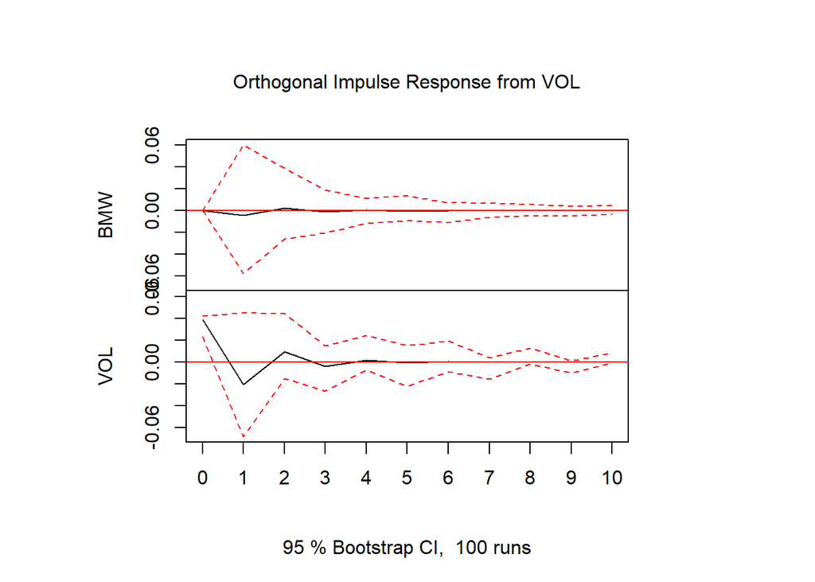

```r
plot(model.ri)
```

### Prediccion

```r
#prediccion
predict(model.var1, n.ahead = 8, ci = 0.95)
```

```
## $BMW
##               fcst      lower     upper        CI
## [1,] -2.971663e-02 -0.2751995 0.2157662 0.2454829
## [2,]  3.148651e-03 -0.2442788 0.2505761 0.2474275
## [3,] -1.344242e-04 -0.2476234 0.2473545 0.2474889
## [4,] -9.554954e-05 -0.2475928 0.2474017 0.2474973
## [5,]  5.990795e-05 -0.2474389 0.2475587 0.2474988
## [6,] -2.787237e-05 -0.2475270 0.2474712 0.2474991
## [7,]  1.213513e-05 -0.2474870 0.2475113 0.2474992
## [8,] -5.186999e-06 -0.2475044 0.2474940 0.2474992
##
## $VOL
##               fcst      lower     upper        CI
## [1,] -2.371857e-02 -0.2678868 0.2204497 0.2441683
## [2,]  6.506443e-04 -0.2480147 0.2493160 0.2486654
## [3,]  9.192776e-04 -0.2484026 0.2502412 0.2493219
## [4,] -5.417473e-04 -0.2499863 0.2489028 0.2494446
## [5,]  2.490744e-04 -0.2492180 0.2497162 0.2494671
## [6,] -1.080979e-04 -0.2495793 0.2493631 0.2494712
## [7,]  4.616239e-05 -0.2494257 0.2495181 0.2494719
## [8,] -1.961995e-05 -0.2494917 0.2494524 0.2494720
```

A partir de los datos concluimos que no se descarta la existencia de causalidad entre los datos de las series temporales de ambas empresas.